# Basket Analysis

Gustavo Cabelo

# 1 Introduction

## 1.1 Goal

Conduct a market basket analysis through R to discover any interesting relationships (or associations) between customer’s transactions and the item(s) they’ve purchased. These associations can then be used to drive sales-oriented initiatives such as recommender systems like the ones used by Amazon and other eCommerce sites..

# 2 Dataset explanation

**2 documents** were used for this analysis:

## 2.1 Transaction File

A CSV dataset with **9835 online transactions**

## 2.2 List of products

A PDF file listing all the products available

- **125 products**
- **17 products type**

# 3 Preprocessing

Loading the libraries

```r
require(dplyr)
require(magrittr)
require(arules)
require(arulesViz)
require(ggplot2)
require(gridExtra)
require(graphics)
require(corrplot)
```

Loading the transaction file in a “transaction” extension. Using this extension instead as normal DF enables us to analyze the composition of each transaction and create association rules with apriori.

```r
transactions <- read.transactions(paste0(getwd(),"/Files/ElectronidexTransactions2017.csv"), format = c("basket","single"), sep = ",", rm.duplicates = F)
```

Understanding the transaction file

```r
summary(transactions)
```

```
## transactions as itemMatrix in sparse format with
##  9835 rows (elements/itemsets/transactions) and
##  125 columns (items) and a density of 0.03506172
##
## most frequent items:
##                     iMac                HP Laptop CYBERPOWER Gamer Desktop
##                     2519                     1909                     1809
##            Apple Earpods        Apple MacBook Air                  (Other)
##                     1715                     1530                    33622
##
## element (itemset/transaction) length distribution:
## sizes
##    0    1    2    3    4    5    6    7    8    9   10   11   12   13   14
##    2 2163 1647 1294 1021  856  646  540  439  353  247  171  119   77   72
##   15   16   17   18   19   20   21   22   23   25   26   27   29   30
##   56   41   26   20   10   10   10    5    3    1    1    3    1    1
##
##    Min. 1st Qu.  Median    Mean 3rd Qu.    Max.
##   0.000   2.000   3.000   4.383   6.000  30.000
##
## includes extended item information - examples:
##                             labels
## 1 1TB Portable External Hard Drive
## 2 2TB Portable External Hard Drive
## 3                   3-Button Mouse
```

Remove the transaction with 0 items

```r
which(size(transactions) == 0)
```

```
## [1] 8707 9506
```

```r
transactions <- transactions[-which(size(transactions) == 0),]
```

Double check if Rows were removed

```r
which(size(transactions) == 0) # Now we are sure there is no longer transactions with items <=0
```

```
## integer(0)
```

# 4 Data Analysis

## 4.1 Visualization

### 4.1.1 Amount of items per transaction

> Histogram

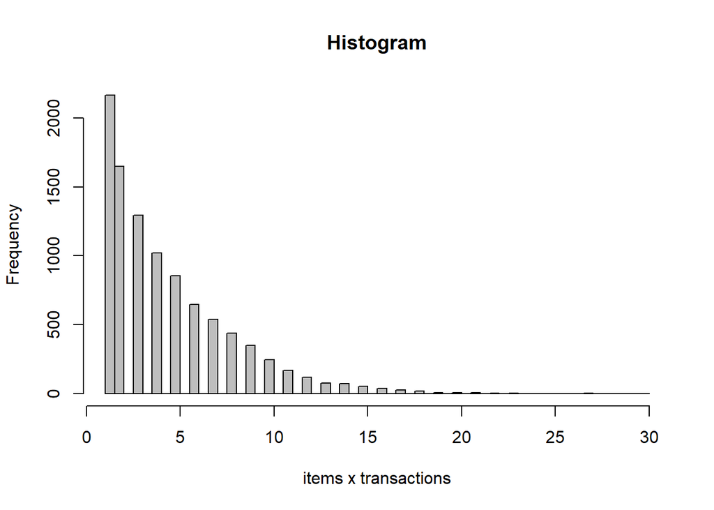

```r
  hist(size(transactions), breaks = 50, col = 'grey', xlab = "items x transactions", main = "Histogram")
```

> Box Plot

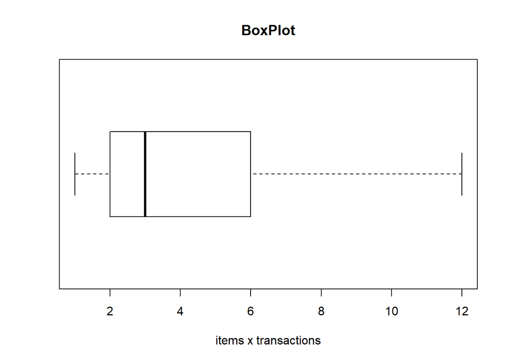

```
In the histogram and in the BoxPlot we can clearly see that the standard transactions have in average between 2 to 6 products
```

```r
boxplot(size(transactions), outline = FALSE, horizontal=TRUE, main="BoxPlot", xlab="items x transactions")
```

### 4.1.2 Best Seller items

> TOP 10 best seller products

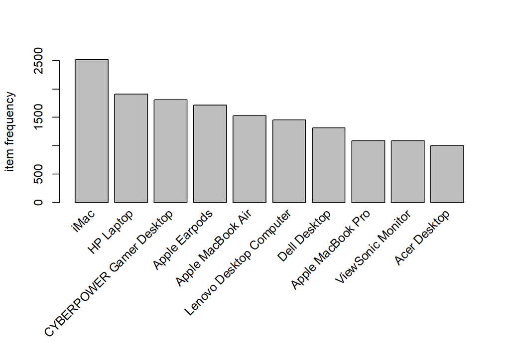

```r
itemFrequencyPlot(transactions, type = c("absolute"), topN = 10, ylab = "item frequency")
```

> TOP10 best sellers as standalone in the purchase basket

The following table shows the purchases made as single items compared to the total times this items has been sold.

```
##                          standalone standalone_perc total
## iMac                            121            4.8%  2519
## HP Laptop                        63            3.3%  1909
## CYBERPOWER Gamer Desktop        109           6.03%  1809
## Apple Earpods                   156            9.1%  1715
## Apple MacBook Air               383          25.03%  1530
## Lenovo Desktop Computer          41           2.82%  1456
## Dell Desktop                     35           2.66%  1318
## Apple MacBook Pro                67           6.16%  1087
## ViewSonic Monitor                25            2.3%  1085
## Acer Desktop                     60           5.99%  1002
```

Was observed that in 9 cases out of the TOP 10 Best Seller items the stand alone sells represent less than 10% of the total sells of these items (Table 1), what means that in more than 90% of these sales there is a clear opportunity for cross-selling them with other items.

> Probability of two products appearing together in the basket

Overview about how the bestseller items correlate in the basket purchases with a second item. Which of them tend to sell as standalone or together with another item.

The values where the item crossed with itself represent its ocurrence (%) as standalone items in the purchase basket.

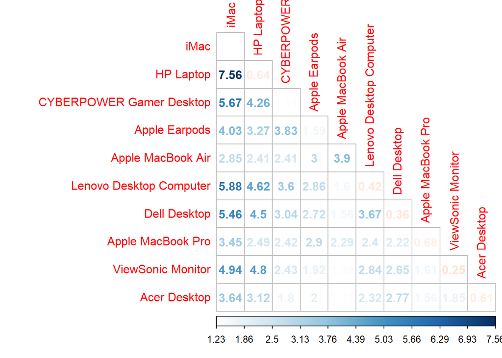

# 5 Association rules

## 5.1 Create rules

**Rules threshold:**

- support > 0.02
- confidence > 0.2
- lift > 1.5

**Metrics Legend:** - LHS: Antecedent - RHS: Consequent - support: indicates how frequently the item / combination appear in the dataset - confidence: indicates the number of times the IF/THEN statement on the data are true. - lift: indicates the ratio between the observed divided by the expected number of occurences.

```r
  rules = apriori(transactions,
                  parameter=list(support = 0.02, confidence = 0.2))

  subrules = rules[quality(rules)$lift > 1.5]

  subrules
```

> Visualize rules The 50 strongest rules after applied the threshold

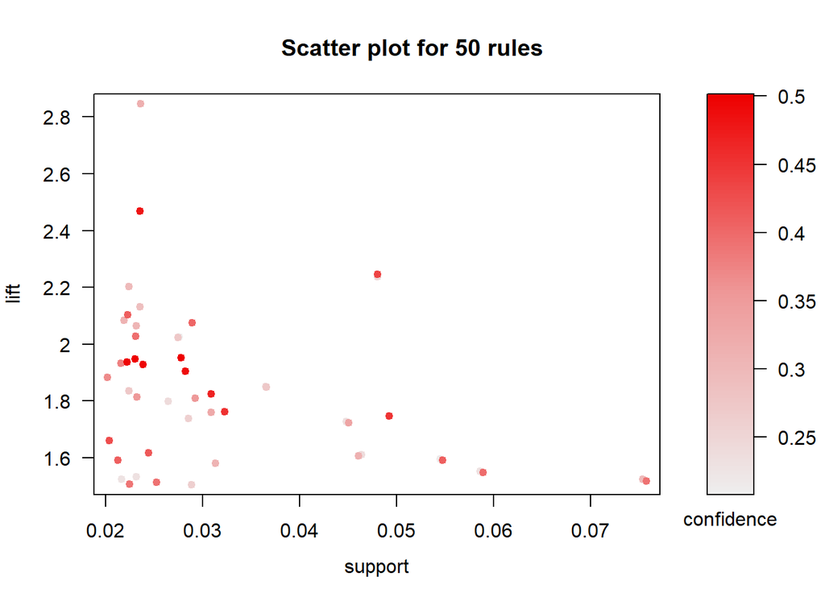

```r
      plot(subrules, measure=c("support","lift"), shading="confidence")
```

- 41 rules with 2 products
- 9 rules with 3 products

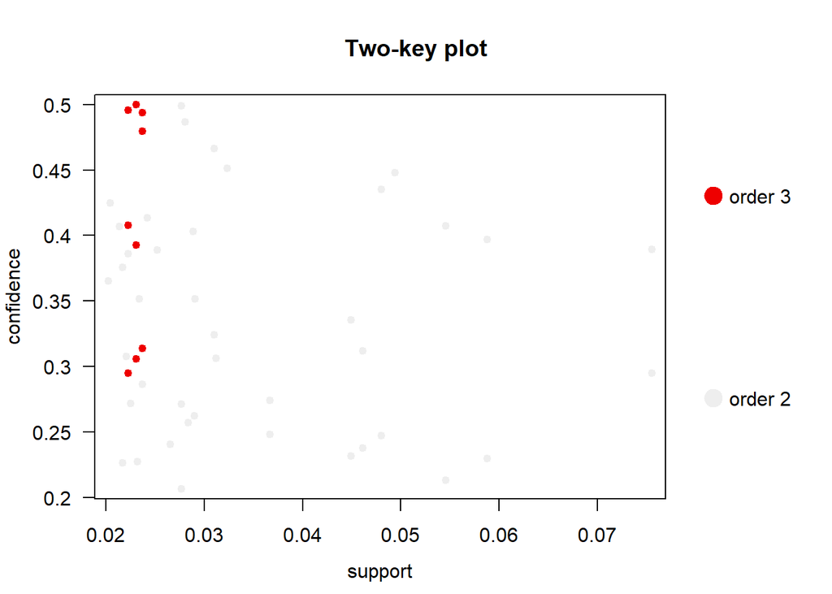

```r
      plot(subrules, shading="order", control=list(main ="Two-key plot"))
```

> List rules

```
##      lhs                                         rhs         support    confidence lift     count
## [1]  {HP Laptop,Lenovo Desktop Computer}      => {iMac}      0.02308553 0.5000000  1.951767 227
## [2]  {ASUS Monitor}                           => {iMac}      0.02766195 0.4990826  1.948185 272
## [3]  {Dell Desktop,HP Laptop}                 => {iMac}      0.02227194 0.4954751  1.934104 219
## [4]  {HP Laptop,ViewSonic Monitor}            => {iMac}      0.02369572 0.4936441  1.926956 233
## [5]  {ASUS 2 Monitor}                         => {iMac}      0.02806875 0.4867725  1.900133 276
## [6]  {iMac,ViewSonic Monitor}                 => {HP Laptop} 0.02369572 0.4794239  2.469447 233
## [7]  {Microsoft Office Home and Student 2016} => {iMac}      0.03101800 0.4663609  1.820455 305
## [8]  {Apple Magic Keyboard}                   => {iMac}      0.03234008 0.4510638  1.760743 318
## [9]  {ViewSonic Monitor}                      => {iMac}      0.04942540 0.4479263  1.748495 486
## [10] {ViewSonic Monitor}                      => {HP Laptop} 0.04800163 0.4350230  2.240745 472
## [11] {Epson Printer}                          => {iMac}      0.02044137 0.4249471  1.658795 201
## [12] {Belkin Mouse Pad}                       => {iMac}      0.02420421 0.4131944  1.612918 238
## [13] {Dell Desktop,iMac}                      => {HP Laptop} 0.02227194 0.4078212  2.100632 219
## [14] {Dell Desktop}                           => {iMac}      0.05461202 0.4074355  1.590438 537
## [15] {ASUS Chromebook}                        => {iMac}      0.02135666 0.4069767  1.588647 210
## [16] {Apple Magic Keyboard}                   => {HP Laptop} 0.02888233 0.4028369  2.074958 284
## [17] {Lenovo Desktop Computer}                => {iMac}      0.05878165 0.3969780  1.549617 578
## [18] {iMac,Lenovo Desktop Computer}           => {HP Laptop} 0.02308553 0.3927336  2.022917 227
## [19] {HP Laptop}                              => {iMac}      0.07556188 0.3892090  1.519290 743
## [20] {Logitech 3-button Mouse}                => {iMac}      0.02522119 0.3887147  1.517361 248
```

## 5.2 Association between 2 Products

### 5.2.1 Reccomended products for baskets that contain as first product

```
**Metrics Legend**
- LHS: Antecedent
- RHS: Consequent
- support: indicates how frequently the item / combination appear in the dataset
- confidence: indicates the number of times the IF/THEN statement on the data are true.
- lift: indicates the ratio between the observed divided by the expected number of occurences.
```

> 1- iMac

```r
  # Create apriori rule
  # For the following items, the code will be hidden. However, to get its results is just to replace "lhs" syntax by the item analyzed.
    rules_iMac = apriori(transactions,
                        parameter=list(support = 0.02, confidence = 0.2, minlen = 2, maxlen = 2),
                        appearance = list(default="rhs" , "lhs" = c("iMac")))
```

```
## set of 4 rules
```

```
##     lhs       rhs                        support    confidence lift     count
## [1] {iMac} => {HP Laptop}                0.07556188 0.2949583  1.519290 743
## [2] {iMac} => {Lenovo Desktop Computer}  0.05878165 0.2294561  1.549617 578
## [3] {iMac} => {CYBERPOWER Gamer Desktop} 0.05674769 0.2215165  1.204075 558
## [4] {iMac} => {Dell Desktop}             0.05461202 0.2131798  1.590438 537
```

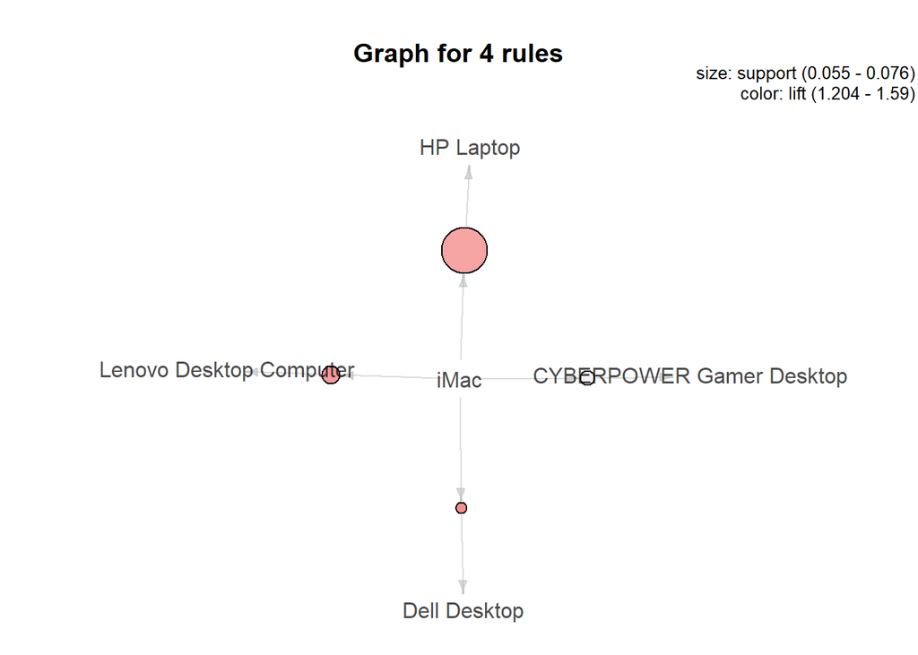

> 2- HPLaptop

```
## set of 5 rules
```

```
##     lhs            rhs                        support    confidence lift     count
## [1] {HP Laptop} => {iMac}                     0.07556188 0.3892090  1.519290 743
## [2] {HP Laptop} => {ViewSonic Monitor}        0.04800163 0.2472499  2.240745 472
## [3] {HP Laptop} => {Lenovo Desktop Computer}  0.04617106 0.2378208  1.606107 454
## [4] {HP Laptop} => {Dell Desktop}             0.04495068 0.2315348  1.727376 442
## [5] {HP Laptop} => {CYBERPOWER Gamer Desktop} 0.04261161 0.2194866  1.193042 419
```

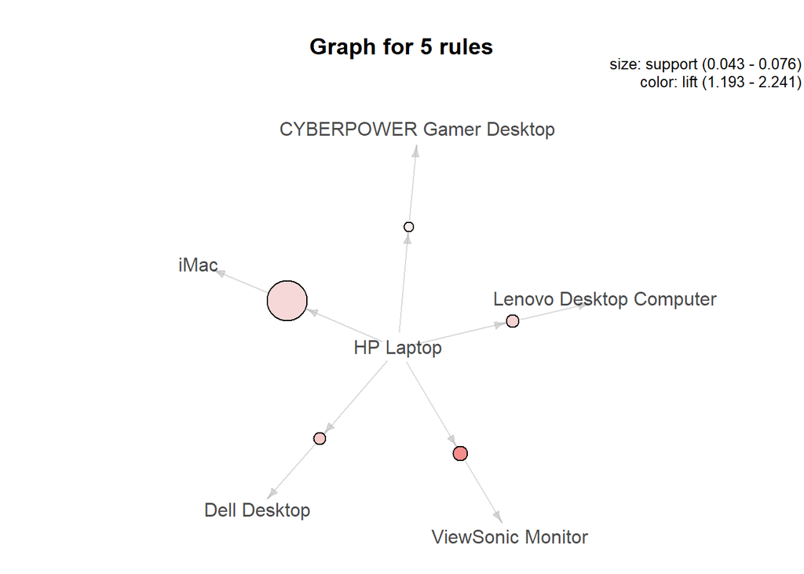

> 3- CyberPower

```
## set of 3 rules
```

```
##     lhs                           rhs             support    confidence lift     count
## [1] {CYBERPOWER Gamer Desktop} => {iMac}          0.05674769 0.3084577  1.204075 558
## [2] {CYBERPOWER Gamer Desktop} => {HP Laptop}     0.04261161 0.2316197  1.193042 419
## [3] {CYBERPOWER Gamer Desktop} => {Apple Earpods} 0.03834028 0.2084024  1.194881 377
```

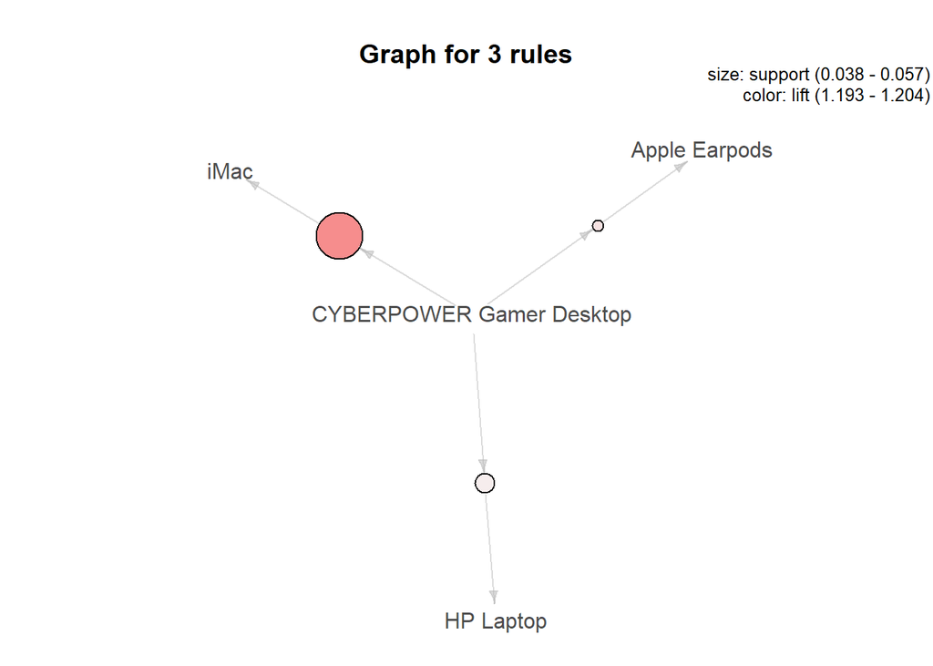

> 4- AppleEarpods

```
## set of 2 rules
```

```
##     lhs                rhs                        support    confidence lift      count
## [1] {Apple Earpods} => {iMac}                     0.04027255 0.2309038  0.9013406 396
## [2] {Apple Earpods} => {CYBERPOWER Gamer Desktop} 0.03834028 0.2198251  1.1948811 377
```

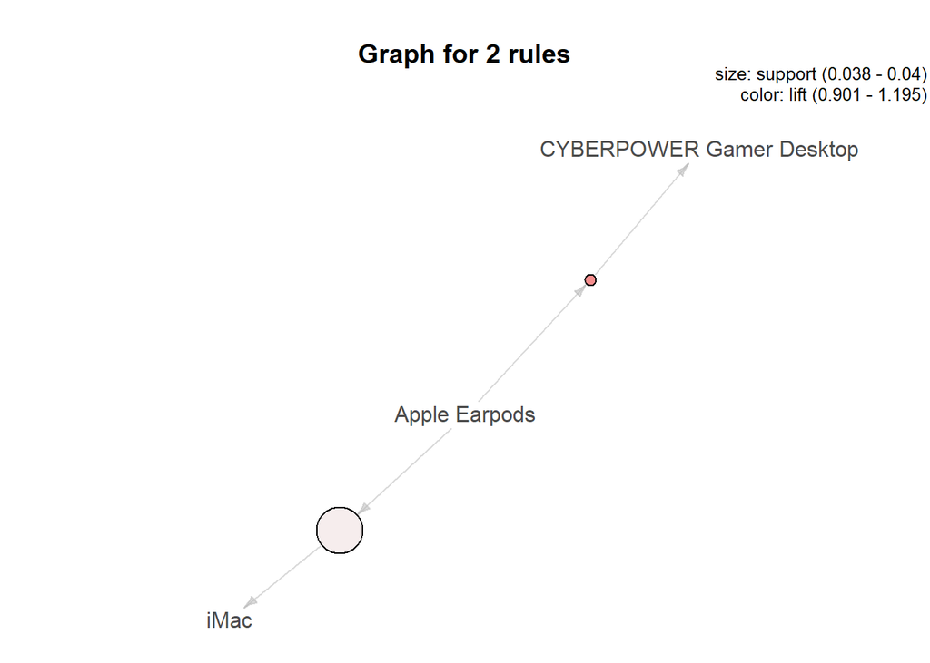

> 5- MacBookAir

```
## set of 4 rules
```

```
##     lhs                    rhs                        support    confidence lift      count
## [1] {Apple MacBook Air} => {Apple Earpods}            0.03000102 0.1928105  1.1054841 295
## [2] {Apple MacBook Air} => {iMac}                     0.02847554 0.1830065  0.7143721 280
## [3] {Apple MacBook Air} => {CYBERPOWER Gamer Desktop} 0.02410251 0.1549020  0.8419851 237
## [4] {Apple MacBook Air} => {HP Laptop}                0.02410251 0.1549020  0.7978790 237
```

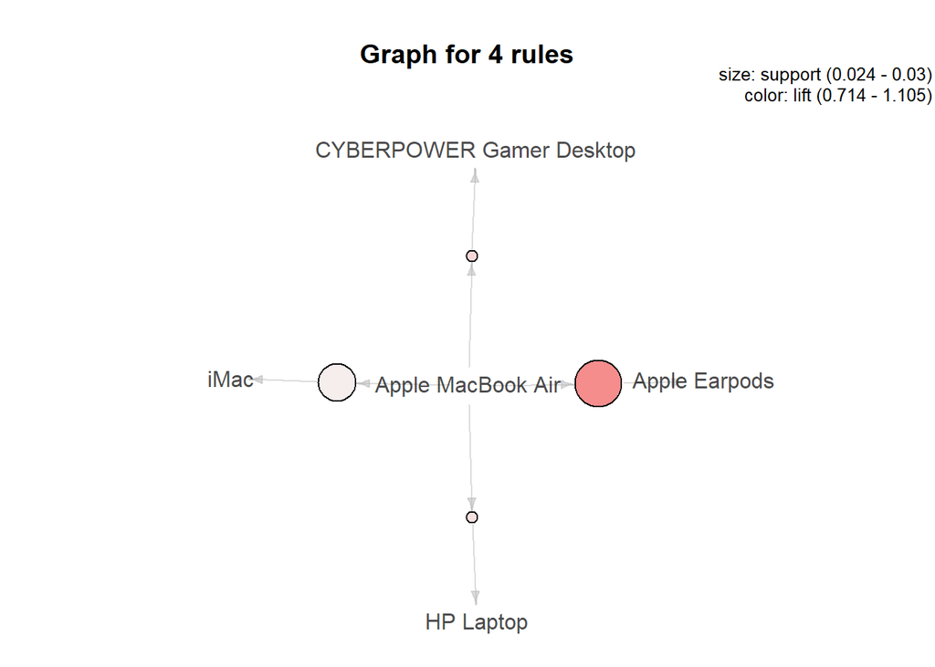

**Confidence level exception** * confidence > 0.15

```
Otherwise no rule would be created.
```

> 6- Lenovo Desktop

```
## set of 4 rules
```

```
##     lhs                          rhs                        support    confidence lift     count
## [1] {Lenovo Desktop Computer} => {iMac}                     0.05878165 0.3969780  1.549617 578
## [2] {Lenovo Desktop Computer} => {HP Laptop}                0.04617106 0.3118132  1.606107 454
## [3] {Lenovo Desktop Computer} => {Dell Desktop}             0.03671311 0.2479396  1.849765 361
## [4] {Lenovo Desktop Computer} => {CYBERPOWER Gamer Desktop} 0.03600122 0.2431319  1.321568 354
```

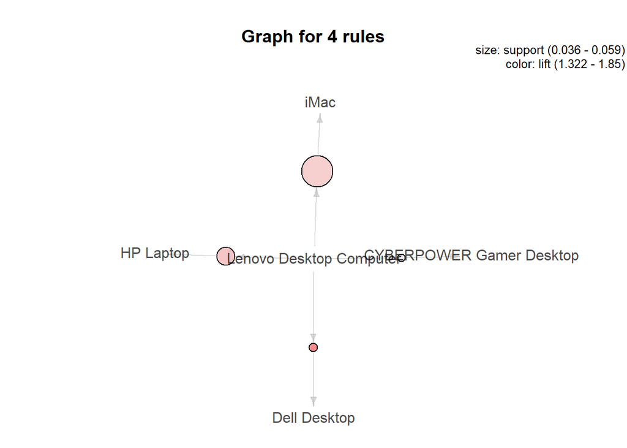

> 7- DellDesktop

```
## set of 6 rules
```

```
##     lhs               rhs                        support    confidence lift     count
## [1] {Dell Desktop} => {iMac}                     0.05461202 0.4074355  1.590438 537
## [2] {Dell Desktop} => {HP Laptop}                0.04495068 0.3353566  1.727376 442
## [3] {Dell Desktop} => {Lenovo Desktop Computer}  0.03671311 0.2738998  1.849765 361
## [4] {Dell Desktop} => {CYBERPOWER Gamer Desktop} 0.03040781 0.2268589  1.233114 299
## [5] {Dell Desktop} => {Acer Desktop}             0.02766195 0.2063733  2.025218 272
## [6] {Dell Desktop} => {Apple Earpods}            0.02715346 0.2025797  1.161496 267
```

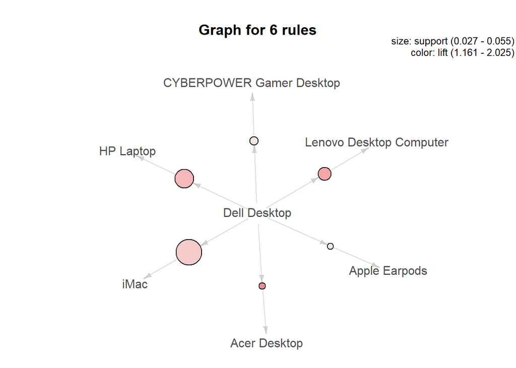

## 5.3 Association between 3 Products

### 5.3.1 Reccomended products for baskets that contain as first product

```
**Metrics Legend**
- LHS: Antecedent
- RHS: Consequent
- support: indicates how frequently the item / combination appear in the dataset
- confidence: indicates the number of times the IF/THEN statement on the data are true.
- lift: indicates the ratio between the observed divided by the expected number of occurences.
```